# Соленость и открытость

ВМ

31 07 2021

Антон, привет! Я немного поиграл с данными, но, увы не до конца понял их структуру. Уж больно они не tidy. Разобрался, как мне кажется, только с Exp1. Итак, излагаю, как понял. Можешь копировать код из чанков и проходить его самостоятельно.

Как я понял, было 60 точек наблюдений. в каждой из которых была какая-то соленость (она менялась по мере проведения эксперимента). Соответственно это все можно описать следующим датасетом.

```r
library(readxl)
library(dplyr)
library(reshape2)
library(lme4)
library(ggplot2)


salinity <- read_excel("Data/Mytred_2021_Salinity.xlsx", sheet = "Exp1_Salinity")

salinity <- as.data.frame(salinity)

head(salinity)
```

```
##   Experiment Observation Duration Salinity
## 1       Exp1       Obs_1        1       24
## 2       Exp1       Obs_2        2       23
## 3       Exp1       Obs_3        3       22
## 4       Exp1       Obs_4        4       21
## 5       Exp1       Obs_5        5       20
## 6       Exp1       Obs_6        6       19
```

Параметр “Duration” я ввел формально, так как это, вероятно, часы, но для модели это не столь важно.

Далее, наблюдения над мидиями дают бинарную переменную отклика, которая при каждом наблюдении имеет значение 1 (открыта) или 0 (закрыта). Исходные данные у тебя даны в широком формате.

```r
myt <- read_excel("Data/Mytred_2021_Salinity.xlsx", sheet = "Exp1_tidy")

myt <- as.data.frame(myt)

head(myt)
```

```
##   Experiment Tank Plank Mussel_ID Expected_Morph True_Morph Length   Www Obs_1
## 1       Exp1    A    TA         1              t          t  29.02 1.033     1
## 2       Exp1    A    TA         2              t          t  25.73 0.964     1
## 3       Exp1    A    TA         3              t          t  28.66 1.492     1
## 4       Exp1    A    TA         4              t          t  23.49 0.704     1
## 5       Exp1    A    TA         5              t          t  26.41 1.032     1
## 6       Exp1    A    TA         6              t          t  23.91 0.676     1
##   Obs_2 Obs_3 Obs_4 Obs_5 Obs_6 Obs_7 Obs_8 Obs_9 Obs_10 Obs_11 Obs_12 Obs_13
## 1     1     1     1     1     1     1     1     1      1      1      0      0
## 2     1     1     1     1     1     1     1     1      1      1      1      0
## 3     1     1     1     1     1     1     1     1      1      1      1      0
## 4     1     1     1     0     0     0     0     0      0      0      0      0
## 5     1     1     1     1     1     1     1     1      1      0      0      0
## 6     1     1     1     1     0     0     1     0      0      0      0      0
##   Obs_14 Obs_15 Obs_16 Obs_17 Obs_18 Obs_19 Obs_20 Obs_21 Obs_22 Obs_23 Obs_24
```

[output cut: 34 more lines]

Поскольку в ряде случаев ожидаемый морфотип не совпал с наблюдаемым (после вскрытия). То я таких мидий удалил, чтобы они не смущали.

```r
# Удаляю мидий с несовпадающими морфотипами
myt2 <- myt %>% filter(Expected_Morph == True_Morph)
```

Широкий формат - это не лучшая форма для работы с данными. Поэтому я переделал все это в длинный формат.

```r
myt2_long <- melt(myt2, id.vars = c("Experiment", "Tank",   "Plank",    "Mussel_ID",    "Expected_Morph",   "True_Morph",   "Length",   "Www"), value.name = "Status", variable.name = "Observation" ) %>% filter(Tank != "C")

# Обрати внимание, что контрольный аквариум я убрал из дальнейшего анализа. Он нужен только для одной цели, чтобы показать, что при неизменной солености от продолжительнсти наблюдений (Duration) ничего не зависит.

# Приделываю к имеющимся данным по состоянию мидий даные по солености и продолжительности
myt2_sal_long <- merge(myt2_long, salinity)

head(myt2_sal_long)
```

```
##   Experiment Observation Tank Plank Mussel_ID Expected_Morph True_Morph Length
## 1       Exp1       Obs_1    A    TA         1              t          t  29.02
## 2       Exp1       Obs_1    A    TA         2              t          t  25.73
## 3       Exp1       Obs_1    A    TA         3              t          t  28.66
## 4       Exp1       Obs_1    A    TA         4              t          t  23.49
## 5       Exp1       Obs_1    A    TA         5              t          t  26.41
## 6       Exp1       Obs_1    A    TA         6              t          t  23.91
##     Www Status Duration Salinity
## 1 1.033      1        1       24
## 2 0.964      1        1       24
## 3 1.492      1        1       24
## 4 0.704      1        1       24
## 5 1.032      1        1       24
## 6 0.676      1        1       24
```

С этим датасетом уже можно что-то делать.

### Строю модель

Здесь все пока довольно кисло, так как longitudial data это вообще херовые данные для моделирования. Было бы, конечно, здорово такой же эксперимент поставить без повторных наблюдений (много аквариумов с разной соленостью, типа по три на каждую соленость, в каждом акватриуме есть пластина, а лучше несколько, с мидиями каждого из морфотипов, ну и одновременно, через какое-то время, регистрируем сколько открытых-закрытых мидий в зависимости от морфотипа). Ну за неимением гербовой пишем на простой…

Модель, что приведена ниже, пока еще не совсем меня устраивает, так как в нее, конечно, надо как-то вкрячить временные корреляции. Как, пока не понял.

Итак, модель

```r
Model1 <- glmer(Status ~ Salinity*True_Morph + Duration + (1|Mussel_ID) + (1|Tank), data = myt2_sal_long, family = binomial(link = "logit"), control=glmerControl(optimizer="bobyqa",optCtrl=list(maxfun=2e5)))

summary(Model1)
```

```
## Generalized linear mixed model fit by maximum likelihood (Laplace
##   Approximation) [glmerMod]
##  Family: binomial  ( logit )
## Formula: Status ~ Salinity * True_Morph + Duration + (1 | Mussel_ID) +
##     (1 | Tank)
##    Data: myt2_sal_long
## Control: glmerControl(optimizer = "bobyqa", optCtrl = list(maxfun = 2e+05))
##
##      AIC      BIC   logLik deviance df.resid
##   1458.0   1500.9   -722.0   1444.0     3353
##
## Scaled residuals:
##      Min       1Q   Median       3Q      Max
## -1138.41    -0.12     0.01     0.14     7.45
##
## Random effects:
##  Groups    Name        Variance Std.Dev.
##  Mussel_ID (Intercept) 1.604    1.2666
##  Tank      (Intercept) 0.174    0.4171
## Number of obs: 3360, groups:  Mussel_ID, 56; Tank, 2
##
## Fixed effects:
##                        Estimate Std. Error z value Pr(>|z|)
## (Intercept)          -21.795082   1.128328 -19.316  < 2e-16 ***
## Salinity               1.480924   0.074080  19.991  < 2e-16 ***
## True_Morpht           -2.829582   1.407118  -2.011  0.04434 *
## Duration               0.065071   0.004944  13.161  < 2e-16 ***
## Salinity:True_Morpht   0.288186   0.106235   2.713  0.00667 **
## ---
## Signif. codes:  0 '***' 0.001 '**' 0.01 '*' 0.05 '.' 0.1 ' ' 1
##
## Correlation of Fixed Effects:
##             (Intr) Salnty Tr_Mrp Duratn
## Salinity    -0.928
## True_Morpht -0.448  0.484
## Duration    -0.528  0.436 -0.050
## Slnty:Tr_Mr  0.401 -0.480 -0.965  0.064
```

Видно, что есть существенное взаимодействие фактора “соленость” и “морфотип”. То есть реакция на соленость у разных морфотипов отличается. Для более понятной трактовки строим визуализацию. Поскольку здесь, подспудно, будет сидеть фактор “Duration”, то красивой визуализации не получается, так как надо как-то встроить в нее эту самую Duration, которая, сцука, еще и значимо влияет (см. summary от модели, где видно, чо чем больше Duration, тем больше доля открытых… типа, привыкают). Для визуалзации пришлось взять среднее значение Duration.

Итак, визуализация

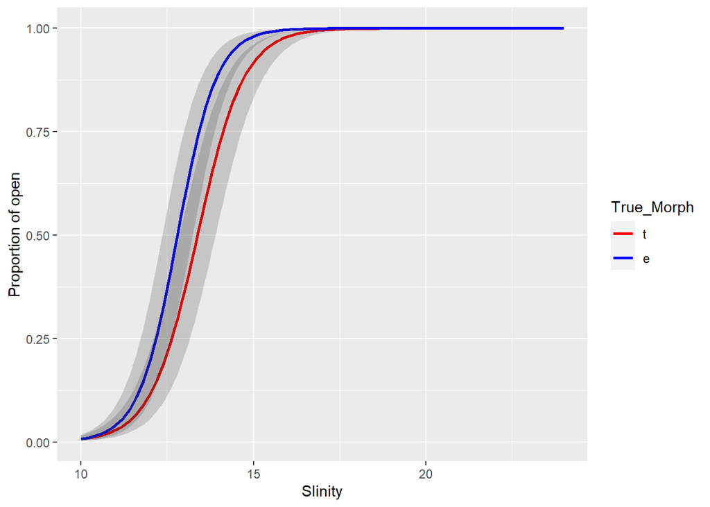

```r
MyData <- expand.grid(Salinity = seq(min(myt2_sal_long$Salinity), max(myt2_sal_long$Salinity), 0.1), True_Morph = c("t", "e"), Duration = mean(myt2_sal_long$Duration))

logit_back <- function(x) exp(x)/(1 + exp(x)) # обратная логит-трансформация

X <- model.matrix(~  Salinity*True_Morph + Duration, data = MyData)
b <- fixef(Model1)

MyData$fit_eta <- X %*% b #Предсказанные значения в шкале логитов
MyData$se_eta <- sqrt(diag(X %*% vcov(Model1) %*% t(X))) #Ошибки в шкале логитов

MyData$fit_pi <- logit_back(MyData$fit_eta) #Предсказанные значения в шкале вероятностей

# Границы доверительного интервала
MyData$lwr <- logit_back(MyData$fit_eta - 1.96 * MyData$se_eta)
MyData$upr <- logit_back(MyData$fit_eta + 1.96 * MyData$se_eta)


Pl <-
  ggplot(MyData, aes(x = Salinity, y = fit_pi)) +
  geom_line(aes(, color = True_Morph), size = 1) +
  geom_ribbon(aes(ymin = lwr, ymax = upr, group = True_Morph), alpha = 0.2) +
  scale_color_manual(values = c("red", "blue")) +
  labs(x = "Slinity", y = "Proportion of open")

Pl
```

Добавим первичку. Но! Помним при этом, что для визуализации мы взяли Duration равное среднему значению. В первичке такого мы себе позволить не сможем. Поэтому первичка не суперски ложится на линии регрессии, хотя, впрочем, бывает и хуже.

```r
# Вычисляем частоту открытых мидий в каждом из наблюдений
myt2_sal_summary <- myt2_sal_long %>% group_by(Tank, Observation, True_Morph) %>% summarize(Salinity = mean(Salinity), Prop_Open = mean(Status == 1)) %>% as.data.frame()

head(myt2_sal_summary)
```

```
##   Tank Observation True_Morph Salinity Prop_Open
## 1    A       Obs_1          e       24 1.0000000
## 2    A       Obs_1          t       24 1.0000000
## 3    A       Obs_2          e       23 0.8461538
## 4    A       Obs_2          t       23 1.0000000
## 5    A       Obs_3          e       22 0.8461538
## 6    A       Obs_3          t       22 1.0000000
```

Наносим полученные значения на график с визуализацией модели.

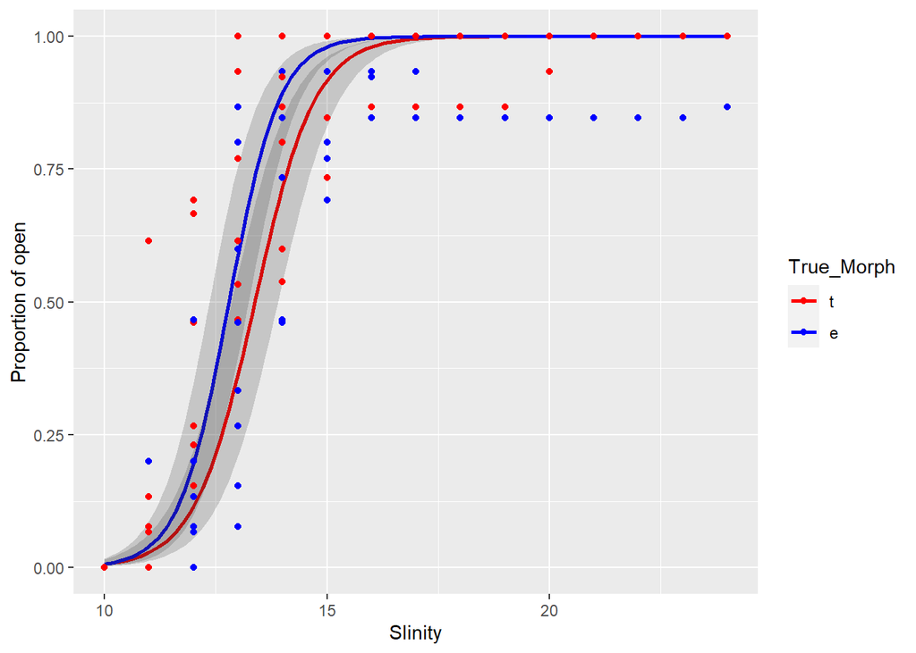

```r
Pl +
  geom_point(data = myt2_sal_summary, aes(x = Salinity, y = Prop_Open, color = True_Morph))
```

Что нужно сделать. 1. Надо вбить данные по всем остальным экспериментам так, чтобы их можно было бы прилинковать к уже иеющимся данным. Идеально все это делать в длинном формате.